# Quick Project # 1 : To analyze a set of Zillow Data

Ki Min Lee / Sakshi Madan

October 14, 2019

# 1 Clear the packages

```r
# Clear environment of variables and functions
rm(list = ls(all=TRUE))


# Clear environment of packages
if(is.null(sessionInfo()$otherPkgs) == FALSE)lapply(paste("package:", names(sessionInfo()$otherPkgs), sep=""), detach, character.only = TRUE, unload = TRUE)
```

# 2 Installing the libraries

```r
library(tidyverse)
library(scales)
library(gridExtra)
library(janitor)
library(GGally)
library(janitor)
library(reshape)
```

```r
library(corrplot)
library(grid)
```

# 3 Load and transform data

```r
# Loading the data
house_sale <- read.csv("/Users/sakshi/Documents/Syllabus/Data Visualization/Quick Project 1/qp1_data.csv")


# Transforming the data
house_sale$price_1000 <- house_sale$price/1000
house_sale$waterfront =as.factor(house_sale$waterfront)
house_sale$zip_code =as.factor(house_sale$zip_code)

mymode <- function(x) {
                 t <- table(x)
                 names(t)[ which.max(t) ]
           }
```

- Using watefront and zipcode as factor variables

# 4 Base EDA Step 1: Uni-variate non-graphical EDA

```r
# Head of the data
head(house_sale)
```

```
##     price bedrooms bathrooms sqft_living sqft_lot floors waterfront view
## 1  221900        3      1.00        1180     5650      1          0    0
## 2  538000        3      2.25        2570     7242      2          0    0
## 3  180000        2      1.00         770    10000      1          0    0
## 4  604000        4      3.00        1960     5000      1          0    0
## 5  510000        3      2.00        1680     8080      1          0    0
## 6 1230000        4      4.50        5420   101930      1          0    0
##   grade condition yr_built yr_renovated zip_code price_1000
## 1     7         3     1955            0    98178      221.9
## 2     7         3     1951         1991    98125      538.0
## 3     6         3     1933            0    98028      180.0
## 4     7         5     1965            0    98136      604.0
## 5     8         3     1987            0    98074      510.0
## 6    11         3     2001            0    98053     1230.0
```

```r
# Summary of the data
summary(house_sale)
```

```
##      price            bedrooms        bathrooms      sqft_living
##  Min.   :  75000   Min.   : 0.000   Min.   :0.000   Min.   :  290
##  1st Qu.: 321950   1st Qu.: 3.000   1st Qu.:1.750   1st Qu.: 1427
##  Median : 450000   Median : 3.000   Median :2.250   Median : 1910
##  Mean   : 540182   Mean   : 3.371   Mean   :2.115   Mean   : 2080
##  3rd Qu.: 645000   3rd Qu.: 4.000   3rd Qu.:2.500   3rd Qu.: 2550
##  Max.   :7700000   Max.   :33.000   Max.   :8.000   Max.   :13540
##
##     sqft_lot           floors      waterfront      view
##  Min.   :    520   Min.   :1.000   0:21450    Min.   :0.0000
##  1st Qu.:   5040   1st Qu.:1.000   1:  163    1st Qu.:0.0000
##  Median :   7618   Median :1.500              Median :0.0000
##  Mean   :  15107   Mean   :1.494              Mean   :0.2343
##  3rd Qu.:  10688   3rd Qu.:2.000              3rd Qu.:0.0000
##  Max.   :1651359   Max.   :3.500              Max.   :4.0000
##
##      grade          condition        yr_built     yr_renovated
##  Min.   : 1.000   Min.   :1.000   Min.   :1900   Min.   :   0.0
##  1st Qu.: 7.000   1st Qu.:3.000   1st Qu.:1951   1st Qu.:   0.0
##  Median : 7.000   Median :3.000   Median :1975   Median :   0.0
##  Mean   : 7.657   Mean   :3.409   Mean   :1971   Mean   :  84.4
##  3rd Qu.: 8.000   3rd Qu.:4.000   3rd Qu.:1997   3rd Qu.:   0.0
##  Max.   :13.000   Max.   :5.000   Max.   :2015   Max.   :2015.0
##
##     zip_code       price_1000
##  98103  :  602   Min.   :  75.0
##  98038  :  590   1st Qu.: 321.9
##  98115  :  583   Median : 450.0
##  98052  :  574   Mean   : 540.2
##  98117  :  553   3rd Qu.: 645.0
##  98042  :  548   Max.   :7700.0
##  (Other):18163
```

```r
# Structure of the data
str(house_sale)
```

```
## 'data.frame':    21613 obs. of  14 variables:
##  $ price       : num  221900 538000 180000 604000 510000 ...
##  $ bedrooms    : int  3 3 2 4 3 4 3 3 3 3 ...
##  $ bathrooms   : num  1 2.25 1 3 2 4.5 2.25 1.5 1 2.5 ...
##  $ sqft_living : int  1180 2570 770 1960 1680 5420 1715 1060 1780 1890 ...
##  $ sqft_lot    : int  5650 7242 10000 5000 8080 101930 6819 9711 7470 6560 ...
##  $ floors      : num  1 2 1 1 1 1 2 1 1 2 ...
##  $ waterfront  : Factor w/ 2 levels "0","1": 1 1 1 1 1 1 1 1 1 1 ...
##  $ view        : int  0 0 0 0 0 0 0 0 0 0 ...
##  $ grade       : int  7 7 6 7 8 11 7 7 7 7 ...
##  $ condition   : int  3 3 3 5 3 3 3 3 3 3 ...
##  $ yr_built    : int  1955 1951 1933 1965 1987 2001 1995 1963 1960 2003 ...
##  $ yr_renovated: int  0 1991 0 0 0 0 0 0 0 0 ...
##  $ zip_code    : Factor w/ 70 levels "98001","98002",..: 67 56 17 59 38 30 3 69 61 24 ...
##  $ price_1000  : num  222 538 180 604 510 ...
```

- Price variables is skewed so will consider median
- We don’t have a lot of data for waterfront houses
- Number of houses seem to have sold uniformly among top 6 zipcodes

# 5 Base EDA Step 2: Uni-variate graphical EDA

## 5.1 Quantitative Variables

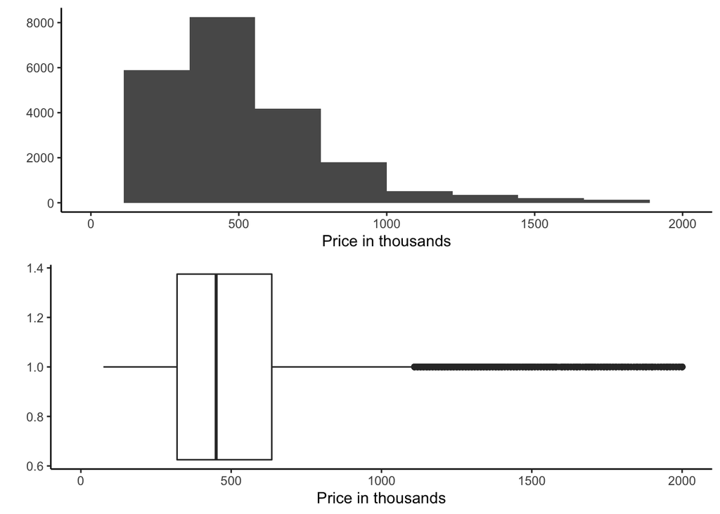

```r
# Uni-variate for price_1000

grid.arrange(

  ggplot(data = house_sale, mapping = aes(x = price_1000)) +
    geom_histogram(bins = 10) +
    xlim(0, 2000) +
    theme_classic() +
    labs(x = "Price in thousands", y = ""),

  ggplot(data = house_sale, mapping = aes(x = 1)) +
    geom_boxplot(mapping = aes(y = price_1000)) +
    coord_flip() +
    theme_classic() +
    labs(x = " ", y = "Price in thousands") +
    ylim(0, 2000)

)
```

- Price is not evenly distributed , there is a huge difference between minimum and maximum
- There is more demand for cheaper houses $500K
- for Price > 1000K - means they are high prices, may be some particular zipcodes have those type of communities?

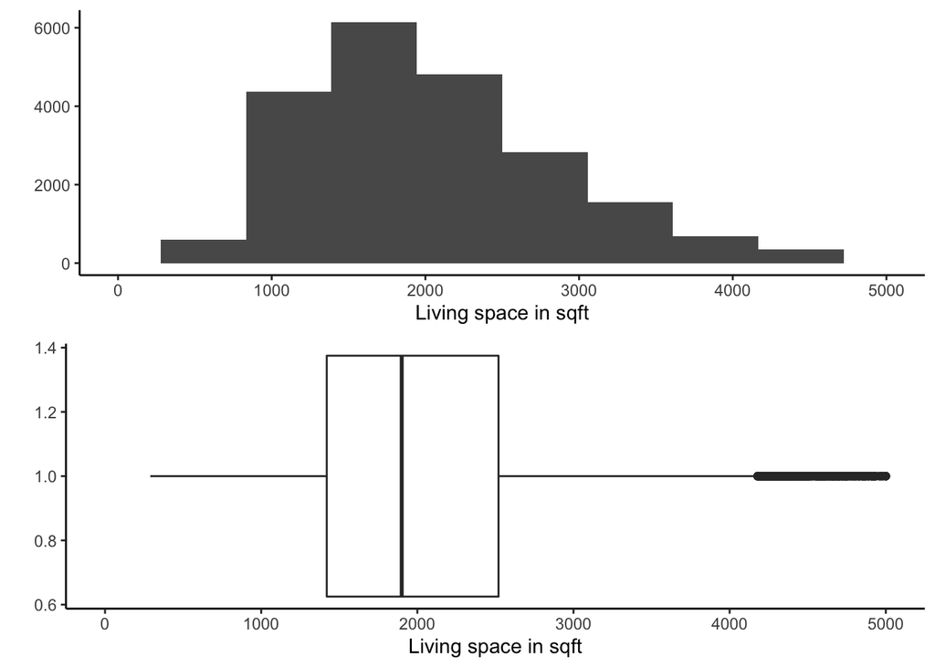

```r
# Uni-variate for sqft_living

grid.arrange(

  ggplot(data = house_sale, mapping = aes(x = sqft_living)) +
    geom_histogram(bins = 10) +
    xlim(0, 5000) +
    theme_classic() +
    labs(x = "Living space in sqft", y = ""),

  ggplot(data = house_sale, mapping = aes(x = 1)) +
    geom_boxplot(mapping = aes(y = sqft_living)) +
    coord_flip() +
    theme_classic() +
    labs(x = " ", y = "Living space in sqft") +
    ylim(0, 5000)

)
```

- Sqft_living is similar to the price distribution which means: Houses < $500K are sold the most and Living Space < 1900Sqft are sold the most 2) House sale with Price > $500K starts to decrease and houses with living space > 1900Sqft starts to decrease
- Is this trend same across all types of bedrooms/bathrooms/floors/grade/condition/zipcodes?
- Mean is almost equal to median

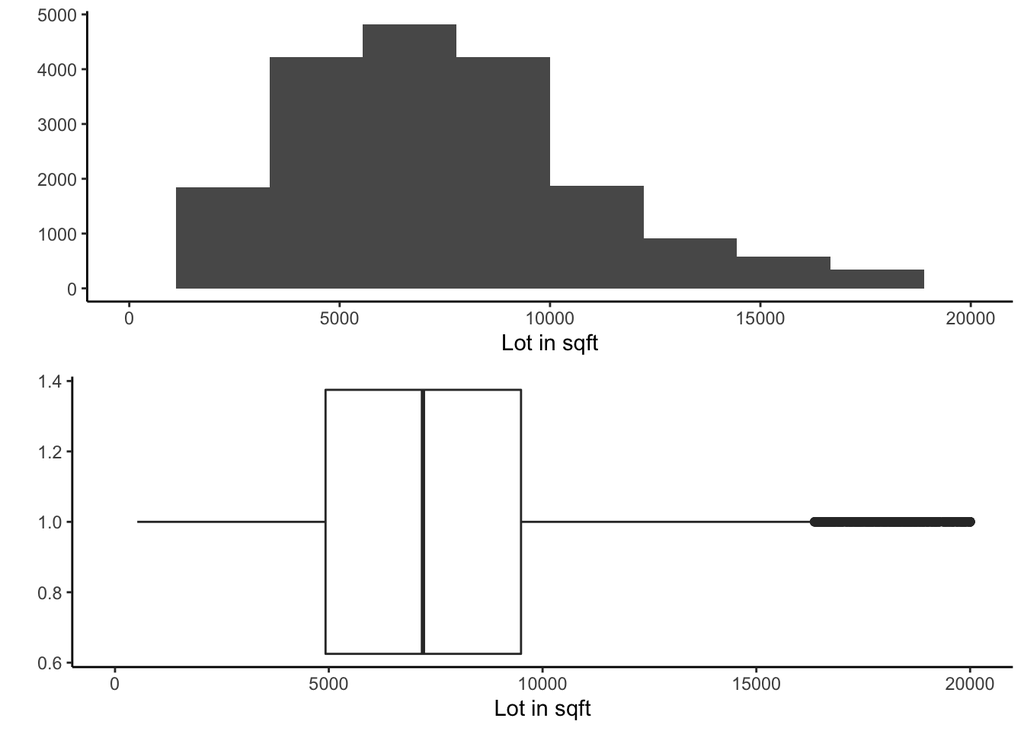

```r
# Uni-variate for sqft_lot

grid.arrange(

  ggplot(data = house_sale, mapping = aes(x = sqft_lot)) +
    geom_histogram(bins = 10) +
    xlim(0, 20000) +
    theme_classic() +
    labs(x = "Lot in sqft", y = ""),

  ggplot(data = house_sale, mapping = aes(x = 1)) +
    geom_boxplot(mapping = aes(y = sqft_lot)) +
    coord_flip() +
    theme_classic() +
    labs(x = " ", y = "Lot in sqft") +
    ylim(0, 20000)

)
```

- Median < Mean
- There are less number of houses sold with big lots and more number of houses sold with smaller lot size

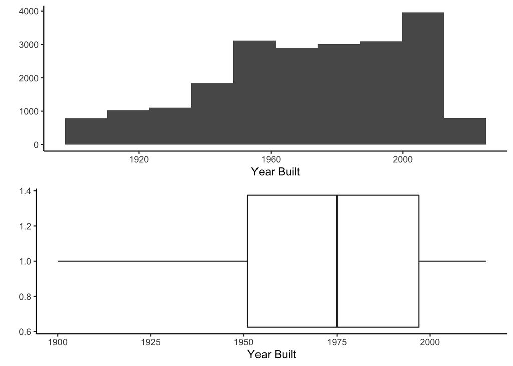

```r
# Uni-variate for Year Built

grid.arrange(

  ggplot(data = house_sale, mapping = aes(x = yr_built)) +
    geom_histogram(bins = 10) +
    theme_classic() +
    labs(x = "Year Built", y = ""),

  ggplot(data = house_sale, mapping = aes(x = 1)) +
    geom_boxplot(mapping = aes(y = yr_built)) +
    coord_flip() +
    theme_classic() +
    labs(x = " ", y = "Year Built")
    #ylim(0, 20000)

)
```

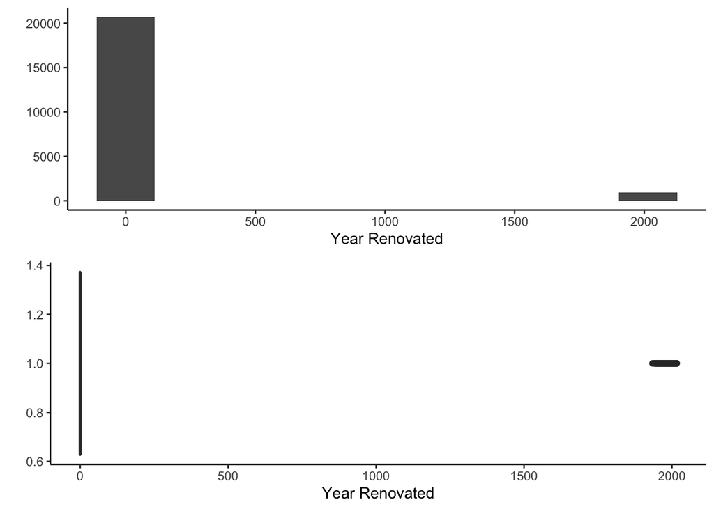

```r
# Uni-variate for Year Renovated

grid.arrange(

  ggplot(data = house_sale, mapping = aes(x = yr_renovated)) +
    geom_histogram(bins = 10) +
    theme_classic() +
    labs(x = "Year Renovated", y = ""),

  ggplot(data = house_sale, mapping = aes(x = 1)) +
    geom_boxplot(mapping = aes(y = yr_renovated)) +
    coord_flip() +
    theme_classic() +
    labs(x = " ", y = "Year Renovated")


)
```

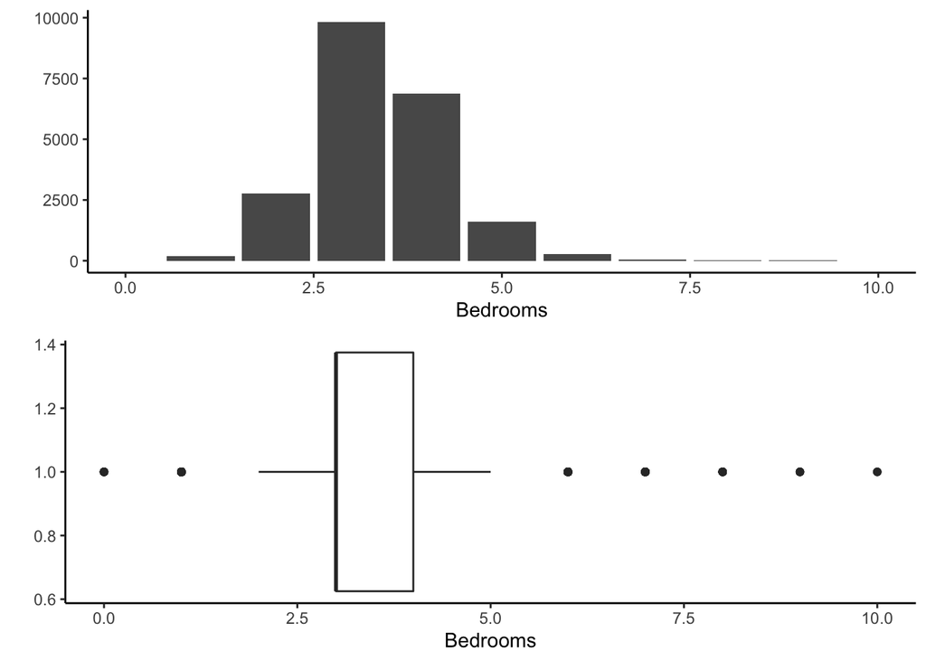

```r
# Uni-variate for bedrooms

grid.arrange(

  ggplot(data = house_sale, mapping = aes(x = bedrooms)) +
    geom_bar(bins = 10) + expand_limits(xlim = 10) +
    labs(x = "Bedrooms", y = "") +
    theme_classic() +
    xlim(0,10),

  ggplot(data = house_sale, mapping = aes(x = 1)) +
    geom_boxplot(mapping = aes(y = bedrooms)) +
    coord_flip() +
    labs(x = " ", y = "Bedrooms") +
    theme_classic() +
    ylim(0, 10),

  ncol = 1

)
```

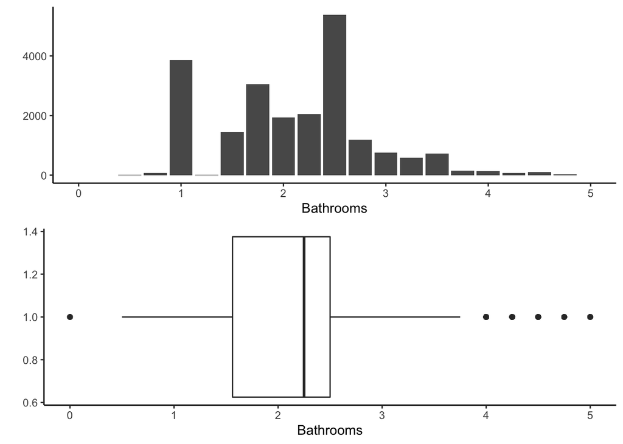

```r
# Uni-variate for bathrooms


grid.arrange(

  ggplot(data = house_sale, mapping = aes(x =  bathrooms)) +
    geom_bar(bins = 10) +
    labs(x = "Bathrooms", y = "") +
    theme_classic() +
    xlim(0,5),

  ggplot(data = house_sale, mapping = aes(x = 1)) +
    geom_boxplot(mapping = aes(y = bathrooms)) +
    coord_flip() +
    theme_classic() +
    labs(x = " ", y = "Bathrooms") +
    ylim(0, 5),

  ncol = 1

)
```

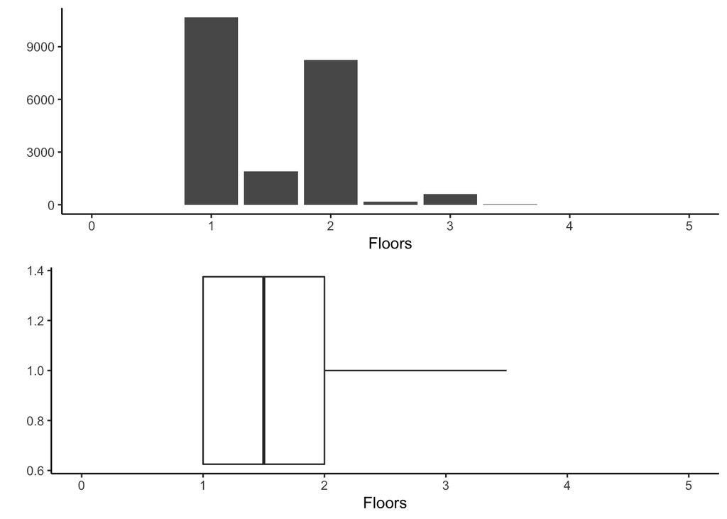

```r
# Uni-variate for floors


grid.arrange(

  ggplot(data = house_sale, mapping = aes(x = floors)) +
    geom_bar(bins = 10) +
    labs(x = "Floors", y = "") +
    theme_classic() +
    xlim(0,5),

  ggplot(data = house_sale, mapping = aes(x = 1)) +
    geom_boxplot(mapping = aes(y = floors)) +
    coord_flip() +
    theme_classic() +
    labs(x = " ", y = "Floors") +
    ylim(0, 5),

  ncol = 1

)
```

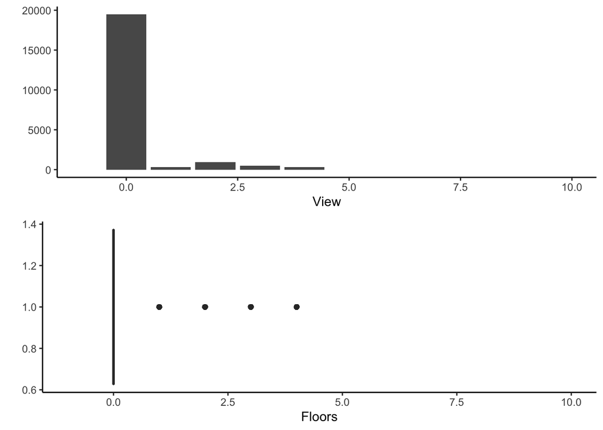

```r
# Uni-variate for view

  grid.arrange(

  ggplot(data = house_sale, mapping = aes(x = view)) +
    geom_bar(bins = 10) +
    labs(x = "View", y = "") +
    theme_classic() +
    xlim(-1,10),

  ggplot(data = house_sale, mapping = aes(x = 1)) +
    geom_boxplot(mapping = aes(y = view)) +
    coord_flip() +
    labs(x = " ", y = "Floors") +
    theme_classic() +
    ylim(-1, 10),

  ncol = 1

  )
```

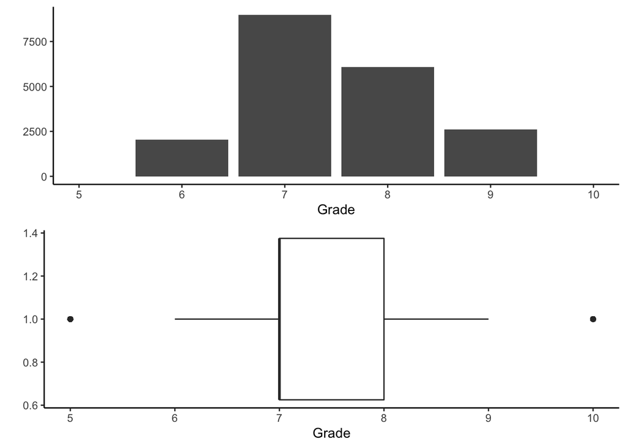

```r
  # Uni-variate for grade

 grid.arrange(

  ggplot(data = house_sale, mapping = aes(grade)) +
    geom_bar(bins = 10) +
    labs(x = "Grade", y = "") +
    theme_classic() +
    xlim(5,10),

  ggplot(data = house_sale, mapping = aes(x = 1)) +
    geom_boxplot(mapping = aes(y = grade)) +
    coord_flip() +
    labs(x = " ", y = "Grade") +
    theme_classic() +
    ylim(5, 10),

  ncol = 1

 )
```

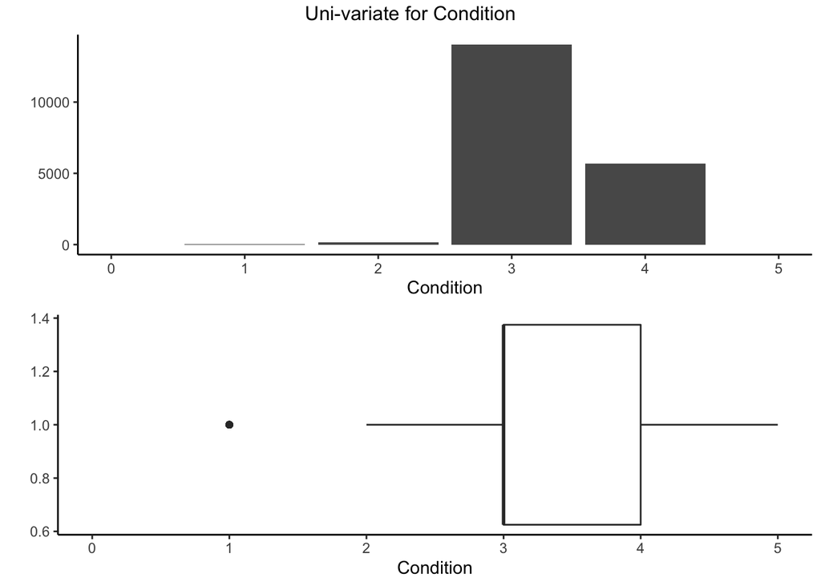

```r
# Uni-variate for condition

  grid.arrange(

  ggplot(data = house_sale, mapping = aes(x = condition)) +
    geom_bar(bins = 10) +
    labs(x = "Condition", y = "") +
    theme_classic() +
    xlim(0,5),

  ggplot(data = house_sale, mapping = aes(x = 1)) +
    geom_boxplot(mapping = aes(y = condition)) +
    coord_flip() +
    theme_classic() +
    labs(x = " ", y = "Condition") +
    ylim(0, 5), top = "Uni-variate for Condition",

  ncol = 1

)
```

- Maximum number of houses sold are with bedrooms 3 and 4
- Maximum number os houses sold are with bathrooms 2.5
- Maximum number os houses sold are with 1 floor
- We don’t have much data for houses with view
- Grade 7 and Condition 3 houses are sold the most
- Does this pattern of different variables remain the same for high priced houses > 1000k?

## 5.2 Categorical Variables

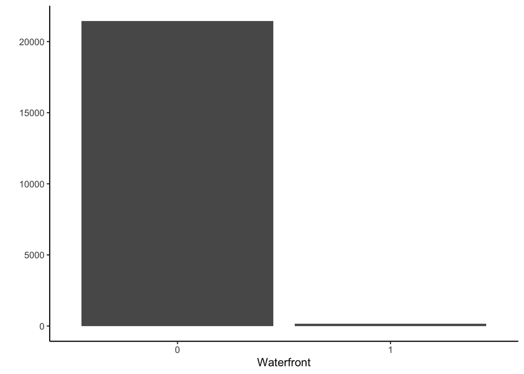

```r
# Uni-variate for waterfront

  ggplot(data = house_sale, mapping = aes(x=waterfront)) +
    geom_bar() +
    theme_classic() +
    labs(x = "Waterfront", y = "" )
```

- As before, we don’t have a lot of data for waterfront houses, we may not consider this variable later

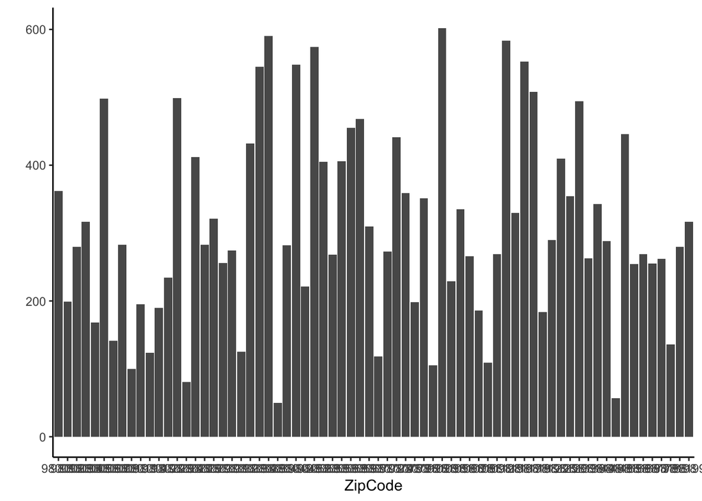

```r
# Uni-variate for zip_code

  ggplot(data = house_sale, mapping = aes(x=zip_code)) +
    geom_bar() +
    theme_classic() +
    labs(x = "ZipCode", y = "")
```

+ Houses are sold within a large number of zipcodes + We are curious about high prices communities, which we are going to dig deep in

# 6 Base EDA Step 3: Multi-variate non - graphical

## 6.1 Categorical

```r
house_sale %>% tabyl(zip_code, waterfront) %>%
  adorn_totals(where = c("row", "col"))
```

```
##  zip_code     0   1 Total
##     98001   362   0   362
##     98002   199   0   199
##     98003   280   0   280
##     98004   316   1   317
##     98005   168   0   168
##     98006   494   4   498
##     98007   141   0   141
##     98008   274   9   283
##     98010   100   0   100
##     98011   195   0   195
##     98014   124   0   124
##     98019   190   0   190
##     98022   234   0   234
##     98023   495   4   499
```

[output cut: 57 more lines]

- The houses with waterfronts are just 0.75% of the total houses, hence we may neglect the waterfront data

## 6.2 Quantitative

```r
house_sale_filter <- house_sale[,c(14,2,3,4,5,6,9,10,11)]
house_sale_filter_cor <- cor(house_sale_filter)
house_sale_filter_cor
```

```
##             price_1000   bedrooms   bathrooms sqft_living     sqft_lot
## price_1000  1.00000000 0.30833837  0.52513407  0.70204372  0.089655208
## bedrooms    0.30833837 1.00000000  0.51588364  0.57667069  0.031703243
## bathrooms   0.52513407 0.51588364  1.00000000  0.75466528  0.087739662
## sqft_living 0.70204372 0.57667069  0.75466528  1.00000000  0.172825661
## sqft_lot    0.08965521 0.03170324  0.08773966  0.17282566  1.000000000
## floors      0.25678570 0.17542894  0.50065317  0.35394929 -0.005200991
## grade       0.66746274 0.35696673  0.66498253  0.76270448  0.113621124
## condition   0.03639192 0.02847210 -0.12498193 -0.05875259 -0.008958250
## yr_built    0.05398183 0.15417807  0.50601944  0.31804877  0.053080367
##                   floors      grade   condition    yr_built
## price_1000   0.256785705  0.6674627  0.03639192  0.05398183
## bedrooms     0.175428935  0.3569667  0.02847210  0.15417807
## bathrooms    0.500653173  0.6649825 -0.12498193  0.50601944
## sqft_living  0.353949290  0.7627045 -0.05875259  0.31804877
## sqft_lot    -0.005200991  0.1136211 -0.00895825  0.05308037
## floors       1.000000000  0.4581825 -0.26376795  0.48931942
## grade        0.458182514  1.0000000 -0.14467367  0.44696320
## condition   -0.263767946 -0.1446737  1.00000000 -0.36141656
## yr_built     0.489319425  0.4469632 -0.36141656  1.00000000
```

- The strong correlation between price_1000 and sqft_living is quite visible here
- Is this correlation of price_1000 and sqft_living remains true amongst other strongly correlated variables bathrooms & grade?

# 7 Base EDA Step 4: Multi-variate graphical

## 7.1 Categorical

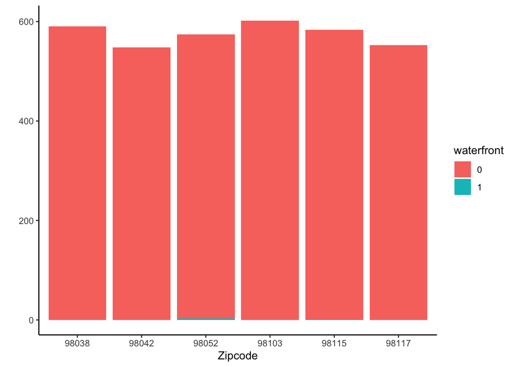

```r
target_zip <- c(98103,98038,98115,98052,98117,98042)

house_sale %>%
  filter(zip_code %in% target_zip) %>%
  ggplot(mapping = aes(x = zip_code, y = 1, fill = waterfront))+
  geom_bar(stat = "identity") +
  theme_classic() +
  labs(x = "Zipcode", y ="")
```

- We have taken the top 6 zipcodes here and found out the same thing is waterfront houses are negligible as compared to others

## 7.2 Quantitative

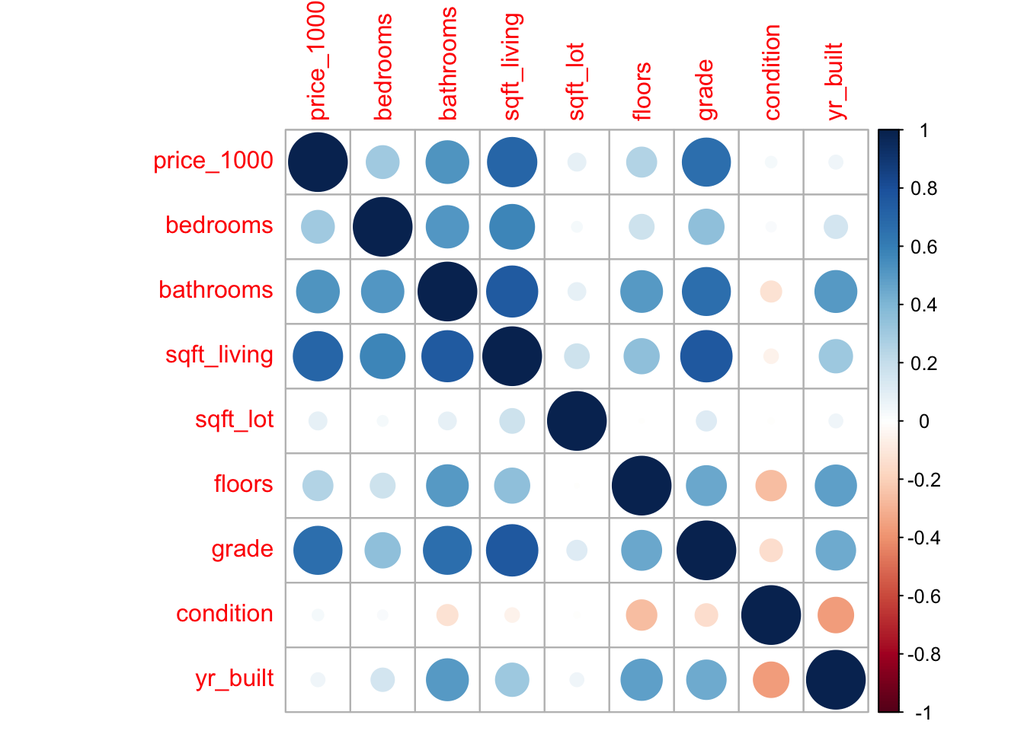

```r
#Correlation plot between all quantitative variables

house_sale_filter <- house_sale[, c(14, 2, 3, 4, 5, 6, 8, 9, 10, 11, 12)]
corrplot(house_sale_filter_cor)
```

- Shows a strong correlation between variables Price_1000 & Sqft_Living. Does the relation hold strong amongst other strong variables bathrooms & grade?

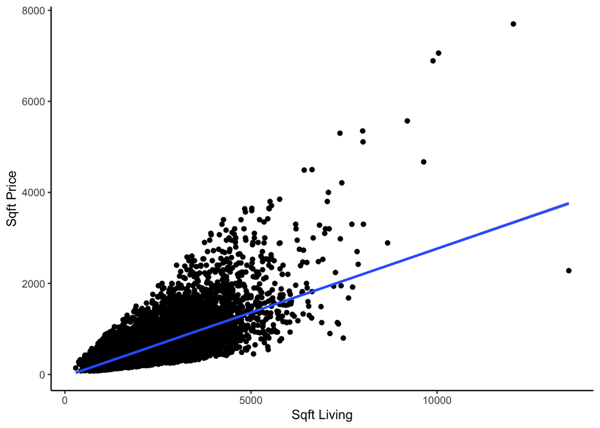

```r
# Multivariate between price & sqft_living
house_sale %>%
  ggplot(mapping = aes(x = sqft_living, y = price_1000)) +
  geom_point() +
  geom_smooth(method = "lm") +
  theme_classic() +
  labs(x = "Sqft Living", y = "Sqft Price")
```

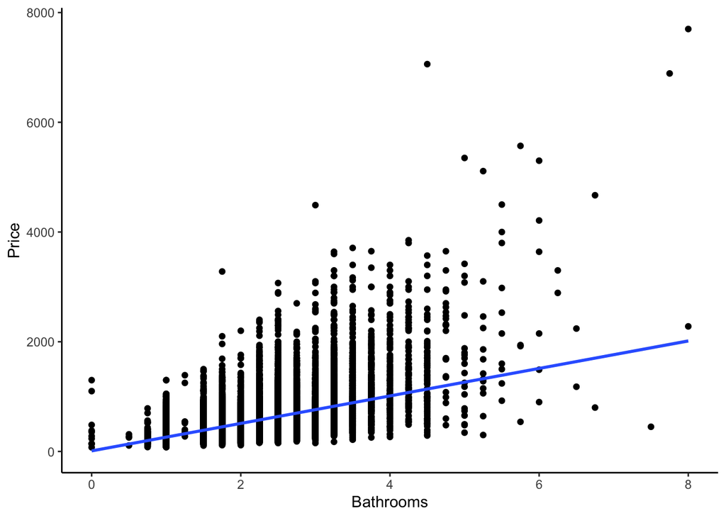

```r
# Multivariate between price & bathrooms
house_sale %>%
  ggplot(mapping = aes(x = bathrooms, y = price_1000)) +
  geom_point() +
  geom_smooth(method = "lm") +
  theme_classic() +
  labs(x = "Bathrooms", y = "Price")
```

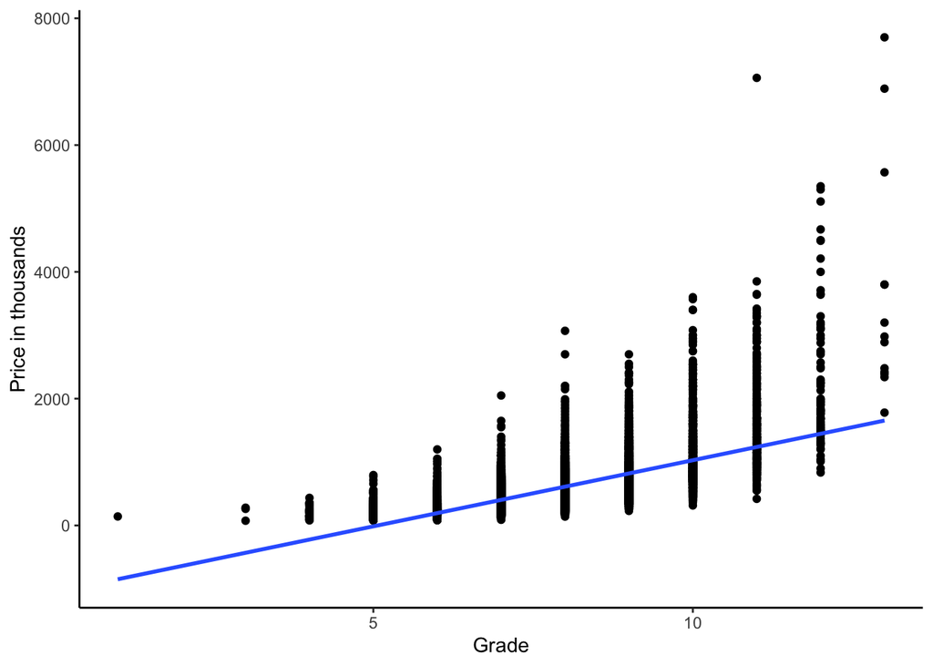

```r
# Multivariate between price and grades
house_sale %>%
  ggplot(mapping = aes(x = grade, y = price_1000)) +
  geom_point() +
  geom_smooth(method = "lm") +
  theme_classic() +
  labs(x = "Grade", y = "Price in thousands")
```

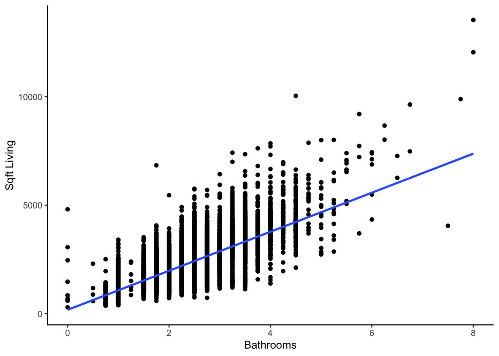

```r
# Multivariate between sqft_living and bathrooms
house_sale %>%
  ggplot(mapping = aes(x = bathrooms, y = sqft_living)) +
  geom_point() +
  geom_smooth(method = "lm") +
  theme_classic() +
  labs(x = "Bathrooms", y = "Sqft Living")
```

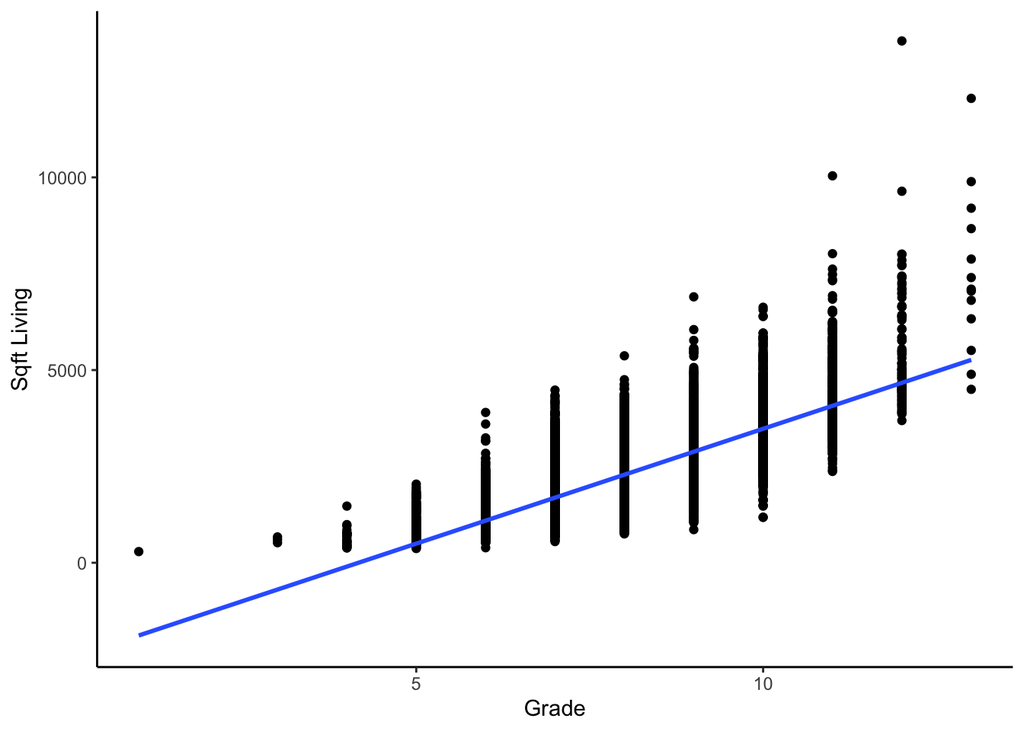

```r
# Multivariate between sqft_living and grades
house_sale %>%
  ggplot(mapping = aes(x = grade, y = sqft_living)) +
  geom_point() +
  geom_smooth(method = "lm") +
  theme_classic() +
  labs(x = "Grade", y = "Sqft Living")
```

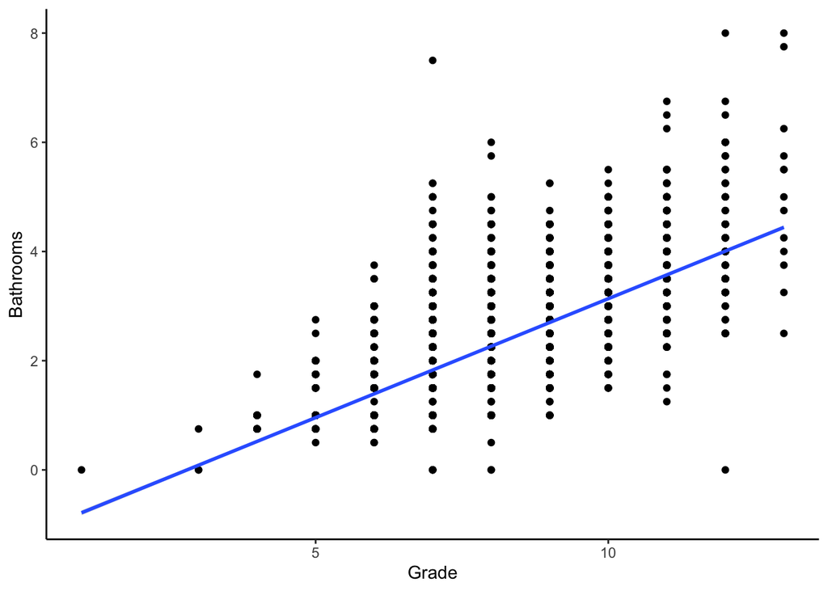

```r
# Multivariate between bathrooms and grades
house_sale %>%
  ggplot(mapping = aes(x = grade, y = bathrooms)) +
  geom_point() +
  geom_smooth(method = "lm") +
  theme_classic() +
  labs(x = "Grade", y = "Bathrooms")
```

- Here we have taken 4 variables which we found as correlated as above
- A strong correlation between all 4 variables looking at the line
- We are going to dig deep into this

## 7.3 Categorical and Quantitative

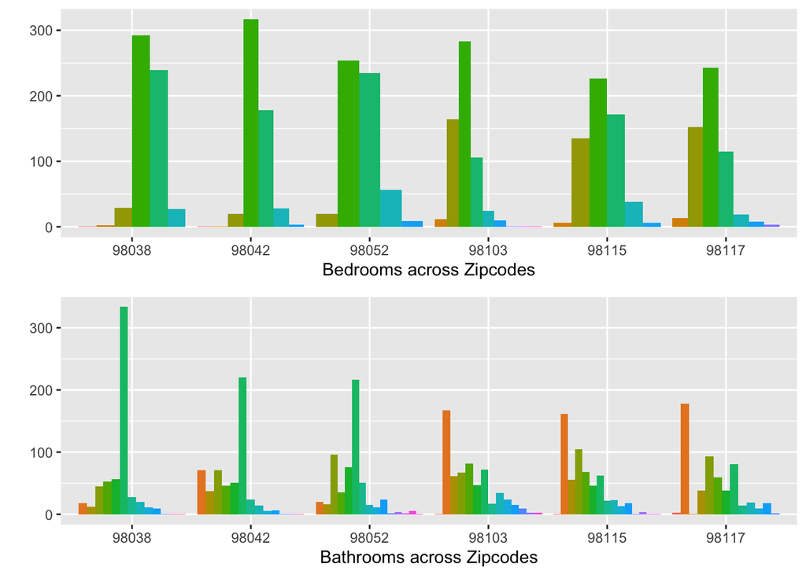

```r
# Multivariate between zipcodes and quantitative variables

grid.arrange(

house_sale %>%
  filter(zip_code %in% target_zip) %>%
  ggplot(mapping = aes(x = zip_code, fill = as.factor(bedrooms))) +
  geom_bar(position = "dodge") +
  labs(x = "Bedrooms across Zipcodes", y = "") +
  theme(legend.position = "none"),

house_sale %>%
  filter(zip_code %in% target_zip) %>%
  ggplot(mapping = aes(x = zip_code, fill = as.factor(bathrooms))) +
  geom_bar(position = "dodge") +
  labs(x = "Bathrooms across Zipcodes", y = "") +
  theme(legend.position = "none")

)
```

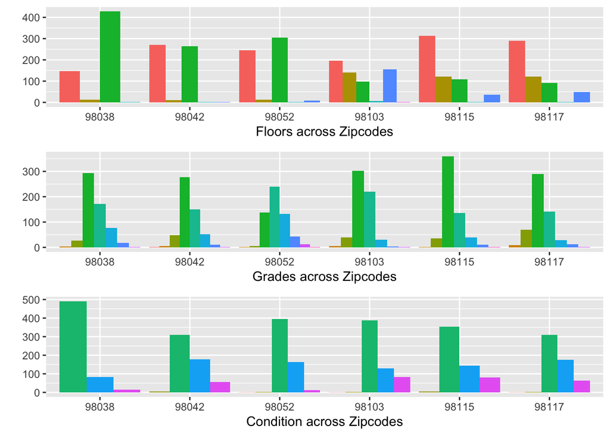

```r
grid.arrange(

house_sale %>%
  filter(zip_code %in% target_zip) %>%
  ggplot(mapping = aes(x = zip_code, fill = as.factor(floors))) +
  geom_bar(position = "dodge") +
  labs(x = "Floors across Zipcodes", y = "") +
  theme(legend.position = "none"),

house_sale %>%
  filter(zip_code %in% target_zip) %>%
  ggplot(mapping = aes(x = zip_code, fill = as.factor(grade))) +
  geom_bar(position = "dodge") +
  labs(x = "Grades across Zipcodes", y = "") +
  theme(legend.position = "none"),

house_sale %>%
  filter(zip_code %in% target_zip) %>%
  ggplot(mapping = aes(x = zip_code, fill = as.factor(condition))) +
  geom_bar(position = "dodge") +
  labs(x = "Condition across Zipcodes", y = "") +
  theme(legend.position = "none")


)
```

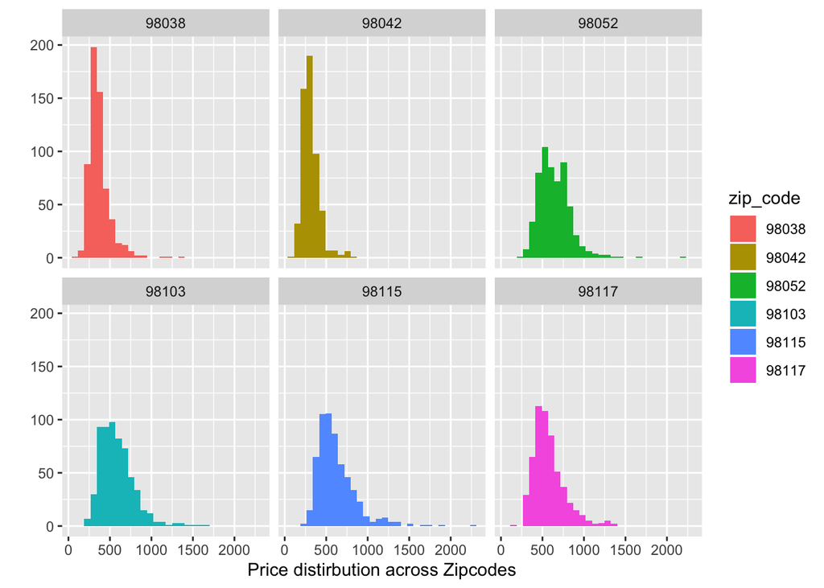

```r
house_sale %>%
  filter(zip_code %in% target_zip) %>%
  ggplot(mapping = aes(x = price_1000, fill = zip_code)) +
  geom_histogram(position = "dodge") +
  facet_wrap(~ zip_code) +
  labs(x = "Price distirbution across Zipcodes", y = "")
```

- We have considered top 6 zipcodes (which have highest sale)
- Shows zipcodes have similar patterns for some variables (Bedrooms, Grades, Conditions), not all
- Looks like the price distribution is not even among them
- We also want to find out high prices communites, price_1000 > 1000k and do this analysis for them

# 8 Detailed EDA : Questions raised in Base EDA

## 8.1 Does the relation between Price, Sqft living, Bathrooms & Grades hold strong amongst each other??

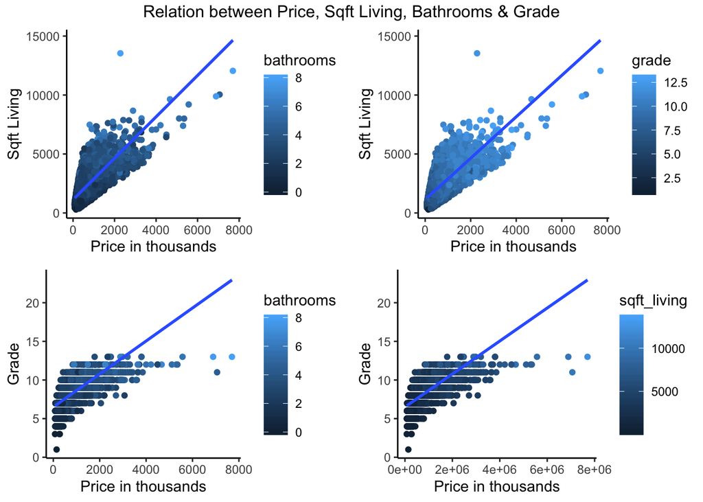

```r
# Multivariate between strongly correlated variables price_1000,  sqft_living, bathrooms and grades

final_graph_1 <- grid.arrange(

house_sale %>%
  ggplot(mapping = aes(x = price_1000, y = sqft_living, color = bathrooms)) +
  geom_point() + theme_classic() +
  geom_smooth(method = lm) +
  labs(x = "Price in thousands", y = "Sqft Living"),

house_sale %>%
  ggplot(mapping = aes(x = price_1000, y = sqft_living, color = grade)) +
  geom_point() + theme_classic() +
  geom_smooth(method = lm) +
  labs(x = "Price in thousands", y = "Sqft Living"),

house_sale %>%
  ggplot(mapping = aes(x = price_1000, y = grade, color = bathrooms)) +
  geom_point() + theme_classic() +
  geom_smooth(method = lm) +
  labs(x = "Price in thousands", y = "Grade"),

house_sale %>%
  ggplot(mapping = aes(x = price, y = grade, color = sqft_living)) +
  geom_point() + theme_classic() +
  geom_smooth(method = lm) +
  labs(x = "Price in thousands", y = "Grade"), top = "Relation between Price, Sqft Living, Bathrooms & Grade"

)
```

```r
final_graph_1
```

```r
ggsave(filename = "final_graph_1.png", plot = final_graph_1)
```

- Since there is a very similar slope between all 4 indicates, we can say that there is a very strong relationship
- How about the outliers in these graphs? These look like the high priced neighborhoods, can we check which zipcodes belong in them?

## 8.2 Which zipcodes have the maximum high price houses? Does the pattern of quantitative variables remain same for high priced houses > 1000k?

```r
house_high <- house_sale %>% filter(price_1000 > 1000)
summarise(house_high, mymode(zip_code))
```

```
##   mymode(zip_code)
## 1            98004
```

```r
house_high_freq <- count(house_high, zip_code)
house_high_freq %>% filter(n>100)
```

```
## # A tibble: 4 x 2
##   zip_code     n
##   <fct>    <int>
## 1 98004      180
## 2 98006      115
## 3 98040      135
## 4 98112      118
```

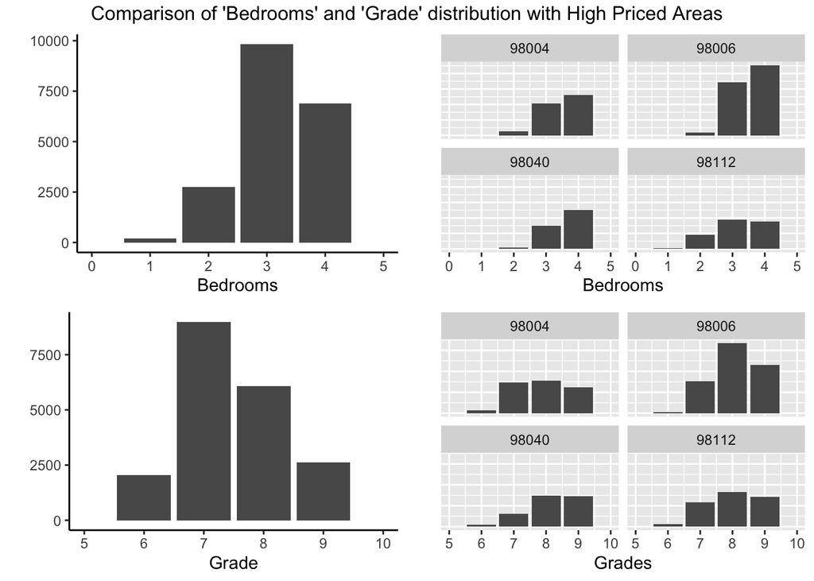

```r
target_high_zip <- c(98004,98006,98040,98112)

final_graph_2 <- grid.arrange(

  house_sale %>%
  ggplot(mapping = aes(x =  bedrooms)) +
  geom_bar(bins = 10) +
  labs(x = "Bedrooms", y = "") +
  theme_classic() +
  xlim(0,5),

  house_sale %>%
  filter(zip_code %in% target_high_zip) %>%
  ggplot(mapping = aes(x = bedrooms)) +
  geom_bar(stat = "count") +
  labs(x = "Bedrooms", y="") +
  xlim(0,5) +
  theme(axis.ticks.y = element_blank(), axis.text.y = element_blank()) +
  facet_wrap(~ zip_code),
  #top = "Comparison of 'Bedrooms' distribution with High Priced Areas",


  house_sale %>%
  ggplot(mapping = aes(x = grade)) +
  geom_bar(bins = 10) +
  labs(x = "Grade", y = "") +
  theme_classic() +
  xlim(5,10),

  house_sale %>%
  filter(zip_code %in% target_high_zip) %>%
  ggplot(mapping = aes(x = grade)) +
  geom_bar(stat = "count") +
  labs(x = "Grades", y="") +
  xlim(5,10) +
  theme(axis.ticks.y = element_blank(), axis.text.y = element_blank()) +
  facet_wrap(~ zip_code),
  top = "Comparison of 'Bedrooms' and 'Grade' distribution with High Priced Areas",

  ncol = 2
)
```

```r
final_graph_2
```

```r
ggsave(filename = "final_graph_2.png", plot = final_graph_2)
```

- We found out that 98004, 98006, 98040 and 98112 fall among the 4 top high priced zipcodes
- Did not consider year_renovated & view because of lesser data as compared to others, but we compared all the variables amongst high valued zipcodes and concluded:
- We see that high priced houses have more of 4 bedrooms
- We also see that they have more of grade 8 houses
- Also, definitely they have bigger sqft_livng and sqft_lot

# 9 Summary

- We need more data to analyze Waterfront Houses, Views, Year Renovated
- Strong correlation between price and sq_ft which holds true amongst bathrooms and grades
- Price Distribution varies for zipcodes
- Zip Code 98004 98006, 98040, 98112 fall amongst high priced neighborhood
- FOr high priced houses, we found that people prefer 4 bedroom and grade 8 houses as compared to 3 and 7 respectively.